# EPI3 - In Class Labs

JMC

Last Update: 03/26/23

## Lab 1 - Review & Surveys

```r
#want to see the html page? go here: https://iamjmc.github.io/epid3_sph/
library(haven)
library(dplyr)
library(tidyr)
library(expss)
#using NYC CHS data - see here for codebook: https://www.nyc.gov/assets/doh/downloads/pdf/episrv/chs2019-codebook.pdf
chs19 <- read_sas("https://www1.nyc.gov/assets/doh/downloads/sas/episrv/chs2019_public.sas7bdat")
keepcols <- c("strata", "wt20_dual", "usborn", "everasthma", "birthsex", "agegroup", "smoker", "insured", "newrace6", "age45up", "age50up", "generalhealth", "education", "exercise19", "pcp19", "wallmold", "colonoscopy10yr19")
mydata <- dplyr::select(chs19, keepcols)


mydata <-  mydata %>%
  mutate(eversmoker=case_when(
  mydata$smoker=="2" ~ 1,
  mydata$smoker=="3" ~ 1,
  mydata$smoker=="1" ~ 0
))

mydata <- transform(mydata,
newrace6 = recode_factor(newrace6, `1`="White/N Afri/MidEastern, non-Hispanic",
                                                 `2`="Black, non-Hispanic",
                                                 `3`="Hispanic",
                                                 `4`="Asian/PI, non-Hispanic",
                                                 `5`="Other, non-Hispanic"),

agegroup = recode_factor(agegroup, `1`="18-24",
                                   `2`="25-44",
                                   `3`="45-64",
                                   `4`="65+",
                                   `.d`="Don't Know",
                                   `.r`= "Refused"),

education = recode_factor(education, `1`="Less than HS",
                                    `2`="High school grad",
                                    `3`="Some college",
                                    `4`="College graduate",
                                    `.d`="Don’t know",
                                    `.r`="Refused"),
eversmoker = recode_factor(eversmoker, `0`="Non Smoker",
                                   `1` ="Smoker"),
birthsex = recode_factor(birthsex, `1`="Male",
                                 `2`="Female"),
insured = recode_factor(insured, `1`="Yes, insured",
                                `2`="No, uninsured"),
everasthma= recode_factor(everasthma, `1` = "Yes, Asthma",
                                      `2`="No Asthma"),
usborn= recode_factor(usborn, `1` = "US Born",
                                      `2`="Foreign Born"),
exercise19= recode_factor(exercise19, `1` = "Yes",
                                      `2`="No"),
wallmold= recode_factor(wallmold, `1` = "Yes",
                                      `2`="No"),
colonoscopy10yr19 = recode_factor(colonoscopy10yr19, `1`="Less than 10 yrs ago",
                                  `2` = "Never or >=10yr"),
pcp19 = recode_factor(pcp19,`1`= "Yes PCP",
                        `2`= "No PCP" )
)
mydata = apply_labels(mydata,
                      insured = "Insured?",
                      birthsex = "Birth Sex",
                      colonoscopy10yr19 = "Colonoscopy in last 10 years"
)

#pesky missing asthma data - if I don't delete this then table 1 will not be able to be stratified
mydata <- mydata %>%
           filter(!is.na(everasthma))

#check content of the data
summary(mydata)
```

```
##      strata           wt20_dual                usborn           everasthma
##  Min.   :20191101   Min.   :  12.74   US Born     :4937   Yes, Asthma:1247
##  1st Qu.:20191502   1st Qu.: 186.78   Foreign Born:3800   No Asthma  :7530
##  Median :20193307   Median : 415.31   NA's        :  40
##  Mean   :20193193   Mean   : 737.94
##  3rd Qu.:20193501   3rd Qu.: 882.07
##  Max.   :20199599   Max.   :5491.26
##
##    birthsex     agegroup        smoker               insured
##  Male  :3841   18-24: 653   Min.   :1.000   Yes, insured :7654
##  Female:4906   25-44:3129   1st Qu.:1.000   No, uninsured: 883
##  NA's  :  30   45-64:2815   Median :1.000   NA's         : 240
##                65+  :2164   Mean   :1.546
##                NA's :  16   3rd Qu.:2.000
##                             Max.   :3.000
##                             NA's   :50
##                                   newrace6       age45up         age50up
##  White/N Afri/MidEastern, non-Hispanic:2976   Min.   :1.000   Min.   :1.000
##  Black, non-Hispanic                  :1939   1st Qu.:1.000   1st Qu.:1.000
##  Hispanic                             :2405   Median :1.000   Median :2.000
##  Asian/PI, non-Hispanic               :1123   Mean   :1.435   Mean   :1.508
##  Other, non-Hispanic                  :  70   3rd Qu.:2.000   3rd Qu.:2.000
##  NA's                                 : 264   Max.   :2.000   Max.   :2.000
##                                               NA's   :3798    NA's   :4518
##  generalhealth              education    exercise19      pcp19      wallmold
##  Min.   :1.000   Less than HS    :1148   Yes :6589   Yes PCP:7519   Yes :1157
##  1st Qu.:2.000   High school grad:1770   No  :2183   No PCP :1210   No  :7544
##  Median :3.000   Some college    :1851   NA's:   5   NA's   :  48   NA's:  76
##  Mean   :2.694   College graduate:3967
##  3rd Qu.:3.000   NA's            :  41
##  Max.   :5.000
##  NA's   :25
##             colonoscopy10yr19      eversmoker
##  Less than 10 yrs ago:3010    Non Smoker:5845
##  Never or >=10yr     :1172    Smoker    :2882
##  NA's                :4595    NA's      :  50
##
##
##
##
```

```r
#two by two table with chi square
table(mydata$birthsex, mydata$eversmoker)
```

```
##
##          Non Smoker Smoker
##   Male         2268   1553
##   Female       3558   1319
```

```r
colSums(table(mydata$birthsex, mydata$eversmoker))
```

```
## Non Smoker     Smoker
##       5826       2872
```

```r
rowSums(table(mydata$birthsex, mydata$eversmoker))
```

```
##   Male Female
##   3821   4877
```

```r
prop.table(table(mydata$birthsex, mydata$eversmoker))
```

```
##
##          Non Smoker    Smoker
##   Male    0.2607496 0.1785468
##   Female  0.4090596 0.1516441
```

```r
chisq.test(mydata$birthsex, mydata$eversmoker, correct=FALSE)
```

```
##
##  Pearson's Chi-squared test
##
## data:  mydata$birthsex and mydata$eversmoker
## X-squared = 179.13, df = 1, p-value < 2.2e-16
```

```r
#3 way table
ftable(mydata$smoker, mydata$birthsex, mydata$insured)
```

```
##           Yes, insured No, uninsured
##
## 1 Male            1922           276
##   Female          3133           323
## 2 Male             451           105
##   Female           382            31
## 3 Male             868            88
##   Female           834            52
```

```r
#another way to do two by two
library(expss)
mydata %>% tab_cols(total(), birthsex) %>%
      tab_cells(insured) %>%
      tab_mis_val(3) %>%
      tab_stat_cases() %>%
      tab_last_sig_cases() %>%
      tab_pivot()
```

|  | #Total |  | Birth Sex Male | Birth Sex Female |
| --- | --- | --- | --- | --- |
| Insured? |  |  |  |  |
| Yes, insured | 7654.0 |  | 3252.0 | 4375.0 |
| No, uninsured | 883.0 |  | 473.0 | 408.0 |
| #Chi-squared p-value | <0.05 |  | <0.05 |  |
| #Total cases | 8537.0 |  | 3725.0 | 4783.0 |

```r
#summary tools 2x2 table
library(summarytools)
library(magrittr)
mydata %$%  # Acts like with(tobacco, ...)
  ctable(x = birthsex, y = eversmoker,
         chisq = TRUE,
         OR    = TRUE,
         RR    = TRUE,
         headings = FALSE,
         prop = "c" ) %>%
  print(method = "render")
```

| **birthsex** | eversmoker Non Smoker | eversmoker Non Smoker | eversmoker Non Smoker | eversmoker Non Smoker | eversmoker Smoker | eversmoker Smoker | eversmoker Smoker | eversmoker Smoker | eversmoker <NA> | eversmoker <NA> | eversmoker <NA> | eversmoker <NA> | Total | Total | Total | Total |
| --- | --- | --- | --- | --- | --- | --- | --- | --- | --- | --- | --- | --- | --- | --- | --- | --- |
| **Male** | 2268 | ( | 38.8% | ) | 1553 | ( | 53.9% | ) | 20 | ( | 40.0% | ) | 3841 | ( | 43.8% | ) |
| **Female** | 3558 | ( | 60.9% | ) | 1319 | ( | 45.8% | ) | 29 | ( | 58.0% | ) | 4906 | ( | 55.9% | ) |
| **<NA>** | 19 | ( | 0.3% | ) | 10 | ( | 0.3% | ) | 1 | ( | 2.0% | ) | 30 | ( | 0.3% | ) |
| **Total** | 5845 | ( | 100.0% | ) | 2882 | ( | 100.0% | ) | 50 | ( | 100.0% | ) | 8777 | ( | 100.0% | ) |

**Χ<sup>2</sup>** = 178.5188 **df** = 1 **p** = .0000 **O.R.** (95% C.I.) = **0.54** (0.49 - 0.59) **R.R.** (95% C.I.) = **0.81** (0.79 - 0.84)

Generated by summarytools 1.0.1 ([R](https://www.r-project.org/) version 4.2.2)  
2023-03-26

```r
library(survey)
library(sjstats)
svy <-
  svydesign(
    ids = ~ 1,
    strat = ~ strata,
    weights =  ~ wt20_dual,
    data = mydata,
    nest = TRUE,
    na.rm = TRUE
  )
#summary(svy)
#see means within the survey
mean(mydata$smoker, na.rm=TRUE)
```

```
## [1] 1.546465
```

```r
svymean(~eversmoker, design=svy, strata = ~strata, weight = ~wt20_dual, data = mydata, na.rm=TRUE)
```

```
##                        mean     SE
## eversmokerNon Smoker 0.6927 0.0077
## eversmokerSmoker     0.3073 0.0077
```

```r
#see smoker mean stratified by birthsex
svyby(~eversmoker, ~birthsex, svy, svymean, na=TRUE)
```

```
##        birthsex eversmokerNon Smoker eversmokerSmoker se.eversmokerNon Smoker
## Male       Male            0.6227495        0.3772505             0.012142801
## Female   Female            0.7535454        0.2464546             0.009557356
##        se.eversmokerSmoker
## Male           0.012142801
## Female         0.009557356
```

```r
svytable(~eversmoker+birthsex, svy)
```

```
##             birthsex
## eversmoker        Male    Female
##   Non Smoker 1853981.2 2601421.2
##   Smoker     1123108.7  850820.8
```

```r
svychisq(~eversmoker+birthsex, svy)
```

```
##
##  Pearson's X^2: Rao & Scott adjustment
##
## data:  svychisq(~eversmoker + birthsex, svy)
## F = 72.011, ndf = 1, ddf = 8614, p-value < 2.2e-16
```

## Lab 2 - Causality & DAGs

You are interested in assessing whether physical activity( exposure) is causally related to heart disease (outcome). 1. What other variables would you want to include in your DAG? Create a DAG with these variables and identify variables needed for total and direct effects?

```r
library(dagitty)
```

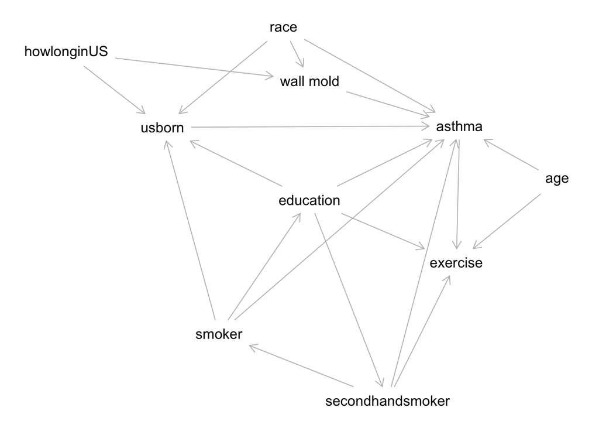

```r
g <- dagitty('
dag {
"wall mold" [pos="-0.433,-0.322"]
age [pos="0.846,0.050"]
asthma [outcome,pos="0.341,-0.153"]
education [pos="-0.435,0.122"]
exercise [pos="0.324,0.355"]
howlonginUS [pos="-1.692,-0.427"]
race [pos="-0.569,-0.519"]
secondhandsmoker [pos="-0.031,0.869"]
smoker [pos="-0.903,0.620"]
usborn [exposure,pos="-1.195,-0.148"]
"wall mold" -> asthma
age -> asthma
age -> exercise
asthma -> exercise
education -> asthma
education -> exercise
education -> secondhandsmoker
education -> usborn
howlonginUS -> "wall mold"
howlonginUS -> usborn
race -> "wall mold"
race -> asthma
race -> usborn
secondhandsmoker -> asthma
secondhandsmoker -> exercise
secondhandsmoker -> smoker
smoker -> asthma
smoker -> education
smoker -> usborn
usborn -> asthma
}
')
plot(g)
```

#Adjusting for total effects= Age, Gender, SES #Adjusting for direct effects = Age, BMI, Diet, Gender, SES

## Lab 3- Hypothesis Testing, Model Development, and Presentation of Results

Just a note: borough would require a DUA and currently not available. The variables noisetraffic, and badairwarning do not exist in CHS19. I use Wall Mold

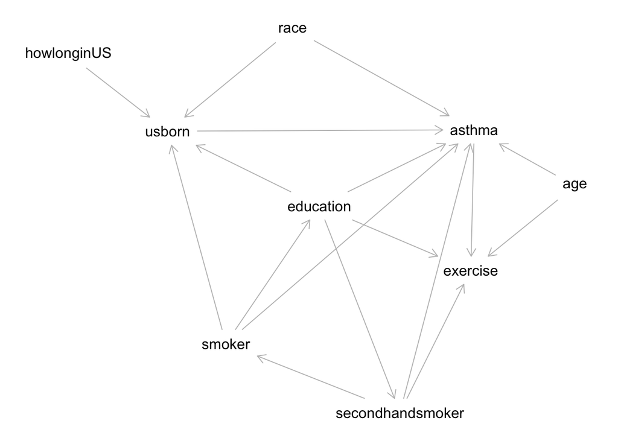

```r
#Draw a dag for association between USBORN and EVERASTHMA
l3dag <- dagitty('
dag {
age [pos="0.846,0.050"]
asthma [outcome,pos="0.341,-0.153"]
education [pos="-0.435,0.122"]
exercise [pos="0.324,0.355"]
howlonginUS [pos="-1.692,-0.427"]
race [pos="-0.569,-0.519"]
secondhandsmoker [pos="-0.031,0.869"]
smoker [pos="-0.903,0.620"]
usborn [exposure,pos="-1.195,-0.148"]
age -> asthma
age -> exercise
asthma -> exercise
education -> asthma
education -> exercise
education -> secondhandsmoker
education -> usborn
howlonginUS -> usborn
race -> asthma
race -> usborn
secondhandsmoker -> asthma
secondhandsmoker -> exercise
secondhandsmoker -> smoker
smoker -> asthma
smoker -> education
smoker -> usborn
usborn -> asthma
}
')
plot (l3dag)
```

adjusting for direct effect - education, howlonginUS, race, smoker OR education, race, smoker, wall mold adjusting for total effect - education, howlonginUS, race, smoker OR education, race, smoker, wall mold

```r
#create table 1
library(table1)
label(mydata$everasthma) <-"Ever had asthma"
label(mydata$birthsex) <- "Birth Sex"
label(mydata$usborn) <-"US Born"
label(mydata$agegroup) <-"Age Group"
label(mydata$eversmoker) <-"Smoke cig"
label(mydata$exercise19) <-"Exercise in past 30 days"
label(mydata$wallmold) <-"Visible mold in last year"
label(mydata$newrace6) <- "Race"
label(mydata$education) <- "Education"
#function for pvalues
pvalue <- function(x, ...) {
    # Construct vectors of data y, and groups (strata) g
    y <- unlist(x)
    g <- factor(rep(1:length(x), times=sapply(x, length)))
    if (is.numeric(y)) {
        # For numeric variables, perform a standard 2-sample t-test
        p <- t.test(y ~ g)$p.value
    } else {
        # For categorical variables, perform a chi-squared test of independence
        p <- chisq.test(table(y, g))$p.value
    }
    # Format the p-value, using an HTML entity for the less-than sign.
    # The initial empty string places the output on the line below the variable label.
    c("", sub("<", "&lt;", format.pval(p, digits=3, eps=0.001)))
}

table1(~usborn + newrace6 + agegroup + birthsex + eversmoker  + wallmold | everasthma, data=mydata, overall="Total", extra.col=list(`P-value`=pvalue))
```

|  | Yes, Asthma (N=1247) | No Asthma (N=7530) | Total (N=8777) | P-value |
| --- | --- | --- | --- | --- |
| US Born |  |  |  |  |
| US Born | 897 (71.9%) | 4040 (53.7%) | 4937 (56.2%) | <0.001 |
| Foreign Born | 347 (27.8%) | 3453 (45.9%) | 3800 (43.3%) |  |
| Missing | 3 (0.2%) | 37 (0.5%) | 40 (0.5%) |  |
| Race |  |  |  |  |
| White/N Afri/MidEastern, non-Hispanic | 369 (29.6%) | 2607 (34.6%) | 2976 (33.9%) | <0.001 |
| Black, non-Hispanic | 323 (25.9%) | 1616 (21.5%) | 1939 (22.1%) |  |
| Hispanic | 411 (33.0%) | 1994 (26.5%) | 2405 (27.4%) |  |
| Asian/PI, non-Hispanic | 89 (7.1%) | 1034 (13.7%) | 1123 (12.8%) |  |
| Other, non-Hispanic | 8 (0.6%) | 62 (0.8%) | 70 (0.8%) |  |
| Missing | 47 (3.8%) | 217 (2.9%) | 264 (3.0%) |  |
| Age Group |  |  |  |  |
| 18-24 | 115 (9.2%) | 538 (7.1%) | 653 (7.4%) | 0.193 |
| 25-44 | 423 (33.9%) | 2706 (35.9%) | 3129 (35.7%) |  |
| 45-64 | 414 (33.2%) | 2401 (31.9%) | 2815 (32.1%) |  |
| 65+ | 294 (23.6%) | 1870 (24.8%) | 2164 (24.7%) |  |
| Missing | 1 (0.1%) | 15 (0.2%) | 16 (0.2%) |  |
| Birth Sex |  |  |  |  |
| Male | 468 (37.5%) | 3373 (44.8%) | 3841 (43.8%) | <0.001 |
| Female | 778 (62.4%) | 4128 (54.8%) | 4906 (55.9%) |  |
| Missing | 1 (0.1%) | 29 (0.4%) | 30 (0.3%) |  |
| Smoke cig |  |  |  |  |
| Non Smoker | 793 (63.6%) | 5052 (67.1%) | 5845 (66.6%) | 0.0559 |
| Smoker | 446 (35.8%) | 2436 (32.4%) | 2882 (32.8%) |  |
| Missing | 8 (0.6%) | 42 (0.6%) | 50 (0.6%) |  |
| Visible mold in last year |  |  |  |  |
| Yes | 254 (20.4%) | 903 (12.0%) | 1157 (13.2%) | <0.001 |
| No | 980 (78.6%) | 6564 (87.2%) | 7544 (86.0%) |  |
| Missing | 13 (1.0%) | 63 (0.8%) | 76 (0.9%) |  |

```r
#create table 2
library(gtsummary)
library(broom)
mydata$everasthma <- relevel(mydata$everasthma, ref = 2)
mydata$usborn <- relevel(mydata$usborn, ref = 2) #have to make sure i have correct reference group
#unadjusted model - adjusting for total and direct effect - education, race, smoker
fit.usborn <- glm(everasthma~usborn,
                  data = mydata,
                  family="binomial")%>%
tbl_regression(
  exponentiate = TRUE )

fit.education <-glm(everasthma~education,
                   data=mydata,
                   family="binomial") %>%
    tbl_regression(
    exponentiate = TRUE)

fit.race <-glm(everasthma~newrace6,
                   data=mydata,
                   family="binomial") %>%
    tbl_regression(
    exponentiate = TRUE)

fit.eversmoker <- glm(everasthma~eversmoker,
                   data=mydata,
                   family="binomial") %>%
    tbl_regression(
    exponentiate = TRUE)

fit.wallmold <- glm(everasthma~wallmold,
                   data=mydata,
                   family="binomial") %>%
    tbl_regression(
    exponentiate = TRUE)

#adjusted model
fit.adjusted <-glm(everasthma~usborn + education+newrace6+eversmoker,
                   data=mydata,
                   family="binomial") %>%
    tbl_regression(
    exponentiate = TRUE,
  )

unadjusted <- tbl_stack(list(fit.usborn, fit.education, fit.race, fit.eversmoker))

tbl_merge(list(unadjusted, fit.adjusted), tab_spanner  = c("Unadjusted Analysis", "Adjusted Analysis"))
```

| **Characteristic** | Unadjusted Analysis **OR**<sup>1</sup> | Unadjusted Analysis **95% CI**<sup>1</sup> | Unadjusted Analysis **p-value** | Adjusted Analysis **OR**<sup>1</sup> | Adjusted Analysis **95% CI**<sup>1</sup> | Adjusted Analysis **p-value** |
| --- | --- | --- | --- | --- | --- | --- |
| usborn |  |  |  |  |  |  |
| Foreign Born | — | — |  | — | — |  |
| US Born | 2.21 | 1.94, 2.52 | <0.001 | 2.51 | 2.16, 2.93 | <0.001 |
| Education |  |  |  |  |  |  |
| Less than HS | — | — |  | — | — |  |
| High school grad | 0.85 | 0.69, 1.04 | 0.11 | 0.70 | 0.56, 0.87 | 0.001 |
| Some college | 0.98 | 0.81, 1.20 | 0.9 | 0.75 | 0.60, 0.93 | 0.008 |
| College graduate | 0.71 | 0.59, 0.85 | <0.001 | 0.60 | 0.49, 0.74 | <0.001 |
| Race |  |  |  |  |  |  |
| White/N Afri/MidEastern, non-Hispanic | — | — |  | — | — |  |
| Black, non-Hispanic | 1.41 | 1.20, 1.66 | <0.001 | 1.45 | 1.22, 1.72 | <0.001 |
| Hispanic | 1.46 | 1.25, 1.70 | <0.001 | 1.62 | 1.37, 1.92 | <0.001 |
| Asian/PI, non-Hispanic | 0.61 | 0.47, 0.77 | <0.001 | 1.01 | 0.77, 1.31 | >0.9 |
| Other, non-Hispanic | 0.91 | 0.40, 1.81 | 0.8 | 0.99 | 0.41, 2.05 | >0.9 |
| Smoke cig |  |  |  |  |  |  |
| Non Smoker | — | — |  | — | — |  |
| Smoker | 1.17 | 1.03, 1.32 | 0.016 | 1.03 | 0.90, 1.18 | 0.6 |

<sup>1</sup> OR = Odds Ratio, CI = Confidence Interval

## Lab 4 - Interaction

Exposure: Insurance EM: Education Outcome: Colonoscopy

Knol & VanderWeele - Presenting EM 1. Present RR, OR/RD with CI for each stratum of E and X with a single reference category 2. Present RR, OR/RD with CI for E within strata of X 3. Present measures of EM on both additive and multiplicative scales (with CI & P) 4. List confounders for which the relation of E and D was adjusted

Knol - Presenting Interaction 1. Present RR, OR/RD with CI for each stratum of E and B with single reference category 2. Present RR, OR/RD for E on D within strata of B and of B on D within strata of E 3. Present measures of EM on both additive (RERI) and multiplicative scales 4. List confounders for which relation between E/D was adjusted and for which relation between B/D were adjusted

```r
library(summarytools)
#make a variable for 0-45, 45+
mydata <-  mydata %>%
transform(mydata,
age50up = recode_factor(age50up, `1`="50-64 Yrs",
                                      `2`="65+"
))
#1 Look at insurance status and colonoscopy in different strata of education
table1(~insured + colonoscopy10yr19+ education + age50up, data=mydata, overall="Total")
```

|  | Total (N=8777) |
| --- | --- |
| Insured? |  |
| Yes, insured | 7654 (87.2%) |
| No, uninsured | 883 (10.1%) |
| Missing | 240 (2.7%) |
| Colonoscopy in last 10 years |  |
| Less than 10 yrs ago | 3010 (34.3%) |
| Never or >=10yr | 1172 (13.4%) |
| Missing | 4595 (52.4%) |
| Education |  |
| Less than HS | 1148 (13.1%) |
| High school grad | 1770 (20.2%) |
| Some college | 1851 (21.1%) |
| College graduate | 3967 (45.2%) |
| Missing | 41 (0.5%) |
| age50up |  |
| 50-64 Yrs | 2095 (23.9%) |
| 65+ | 2164 (24.7%) |
| Missing | 4518 (51.5%) |

```r
mydata %$%  # First examine insurance and education
  ctable(x=education, y=insured,
         chisq = TRUE,
         OR    = TRUE,
         RR    = TRUE,
         headings = FALSE,
         useNA="no",
         prop = "c" ) %>%
  print(method = "render")
```

| **education** | insured Yes, insured | insured Yes, insured | insured Yes, insured | insured Yes, insured | insured No, uninsured | insured No, uninsured | insured No, uninsured | insured No, uninsured | Total | Total | Total | Total |
| --- | --- | --- | --- | --- | --- | --- | --- | --- | --- | --- | --- | --- |
| **Less than HS** | 860 | ( | 11.3% | ) | 224 | ( | 25.7% | ) | 1084 | ( | 12.8% | ) |
| **High school grad** | 1478 | ( | 19.4% | ) | 233 | ( | 26.7% | ) | 1711 | ( | 20.1% | ) |
| **Some college** | 1627 | ( | 21.3% | ) | 175 | ( | 20.1% | ) | 1802 | ( | 21.2% | ) |
| **College graduate** | 3662 | ( | 48.0% | ) | 240 | ( | 27.5% | ) | 3902 | ( | 45.9% | ) |
| **Total** | 7627 | ( | 100.0% | ) | 872 | ( | 100.0% | ) | 8499 | ( | 100.0% | ) |

**Χ<sup>2</sup>** = 220.5458 **df** = 3 **p** = .0000

Generated by summarytools 1.0.1 ([R](https://www.r-project.org/) version 4.2.2)  
2023-03-26

```r
mydata %$%  # Next colonoscopy and age 45+
  ctable(x=age50up, y=colonoscopy10yr19,
         chisq = TRUE,
         OR    = TRUE,
         RR    = TRUE,
         headings = FALSE,
         useNA="no", #hides missing values
         prop = "c" ) %>%
  print(method = "render")
```

| **age50up** | colonoscopy10yr19 Less than 10 yrs ago | colonoscopy10yr19 Less than 10 yrs ago | colonoscopy10yr19 Less than 10 yrs ago | colonoscopy10yr19 Less than 10 yrs ago | colonoscopy10yr19 Never or > ;=10yr | colonoscopy10yr19 Never or > ;=10yr | colonoscopy10yr19 Never or > ;=10yr | colonoscopy10yr19 Never or > ;=10yr | Total | Total | Total | Total |
| --- | --- | --- | --- | --- | --- | --- | --- | --- | --- | --- | --- | --- |
| **50-64 Yrs** | 1432 | ( | 47.6% | ) | 641 | ( | 54.7% | ) | 2073 | ( | 49.6% | ) |
| **65+** | 1578 | ( | 52.4% | ) | 531 | ( | 45.3% | ) | 2109 | ( | 50.4% | ) |
| **Total** | 3010 | ( | 100.0% | ) | 1172 | ( | 100.0% | ) | 4182 | ( | 100.0% | ) |

**Χ<sup>2</sup>** = 16.8138 **df** = 1 **p** = .0000 **O.R.** (95% C.I.) = **0.75** (0.66 - 0.86) **R.R.** (95% C.I.) = **0.92** (0.89 - 0.96)

Generated by summarytools 1.0.1 ([R](https://www.r-project.org/) version 4.2.2)  
2023-03-26

```r
#make tables by level of education
stby(data    = list(x = mydata$insured, y = mydata$colonoscopy10yr19),
     INDICES = mydata$education,
     FUN     = ctable,
     chisq=TRUE, #no OR/RR here because it is categorical
     useNA="no"
     )
```

```
## Cross-Tabulation, Row Proportions
## insured * colonoscopy10yr19
## Data Frame: mydata
## Group: education = Less than HS
##
##
## --------------- ------------------- ---------------------- ----------------- --------------
##                   colonoscopy10yr19   Less than 10 yrs ago   Never or >=10yr          Total
##         insured
##    Yes, insured                                425 (71.7%)       168 (28.3%)   593 (100.0%)
##   No, uninsured                                 41 (57.7%)        30 (42.3%)    71 (100.0%)
##           Total                                466 (70.2%)       198 (29.8%)   664 (100.0%)
## --------------- ------------------- ---------------------- ----------------- --------------
##
## ----------------------------
##  Chi.squared   df   p.value
## ------------- ---- ---------
##     5.227      1    0.0222
## ----------------------------
##
## Group: education = High school grad
##
##
## --------------- ------------------- ---------------------- ----------------- --------------
##                   colonoscopy10yr19   Less than 10 yrs ago   Never or >=10yr          Total
##         insured
##    Yes, insured                                542 (72.4%)       207 (27.6%)   749 (100.0%)
##   No, uninsured                                 23 (46.9%)        26 (53.1%)    49 (100.0%)
##           Total                                565 (70.8%)       233 (29.2%)   798 (100.0%)
## --------------- ------------------- ---------------------- ----------------- --------------
##
## ----------------------------
##  Chi.squared   df   p.value
## ------------- ---- ---------
##    13.177      1     3e-04
## ----------------------------
##
## Group: education = Some college
##
##
```

[output cut: 15 more lines]

```
##
##
## --------------- ------------------- ---------------------- ----------------- ---------------
##                   colonoscopy10yr19   Less than 10 yrs ago   Never or >=10yr           Total
##         insured
##    Yes, insured                               1282 (75.1%)       425 (24.9%)   1707 (100.0%)
##   No, uninsured                                 35 (52.2%)        32 (47.8%)     67 (100.0%)
##           Total                               1317 (74.2%)       457 (25.8%)   1774 (100.0%)
## --------------- ------------------- ---------------------- ----------------- ---------------
##
## ----------------------------
##  Chi.squared   df   p.value
## ------------- ---- ---------
##    16.4467     1     1e-04
## ----------------------------
```

```r
#2 make new variable for college education
mydata <- mydata %>%
  mutate(college=case_when(
    mydata$education=="College graduate" ~ 1,
    mydata$education!="College graduate" ~ 0
  ))

mydata <- mydata %>%
  mutate(hasinsurance=case_when(
    mydata$insured=="Yes, insured" ~ 1,
    mydata$insured=="No, uninsured" ~ 0
  ))
mydata <- mydata %>%
  mutate(recentcolonoscopy=case_when(
    mydata$colonoscopy10yr19=="Less than 10 yrs ago" ~ 1,
    mydata$colonoscopy10yr19=="Never or >=10yr" ~0
  )
  )


#make tables by college education
stby(data    = list(x = mydata$insured, y = mydata$colonoscopy10yr19),
     INDICES = mydata$college,
     FUN     = ctable,
     chisq=TRUE,
     OR= TRUE,
     RR=TRUE,
     useNA="no"
     )
```

```
## Cross-Tabulation, Row Proportions
## insured * colonoscopy10yr19
## Data Frame: mydata
## Group: college = 0
##
##
## --------------- ------------------- ---------------------- ----------------- ---------------
##                   colonoscopy10yr19   Less than 10 yrs ago   Never or >=10yr           Total
##         insured
##    Yes, insured                               1517 (72.4%)       579 (27.6%)   2096 (100.0%)
##   No, uninsured                                 90 (52.3%)        82 (47.7%)    172 (100.0%)
##           Total                               1607 (70.9%)       661 (29.1%)   2268 (100.0%)
## --------------- ------------------- ---------------------- ----------------- ---------------
##
## ----------------------------
##  Chi.squared   df   p.value
## ------------- ---- ---------
##    29.9817     1       0
## ----------------------------
##
## ----------------------------------
##  Odds Ratio   Lo - 95%   Hi - 95%
## ------------ ---------- ----------
##     2.39        1.74       3.27
## ----------------------------------
##
## ----------------------------------
##  Risk Ratio   Lo - 95%   Hi - 95%
## ------------ ---------- ----------
##     1.38        1.20       1.60
## ----------------------------------
##
## Group: college = 1
##
##
## --------------- ------------------- ---------------------- ----------------- ---------------
##                   colonoscopy10yr19   Less than 10 yrs ago   Never or >=10yr           Total
##         insured
##    Yes, insured                               1282 (75.1%)       425 (24.9%)   1707 (100.0%)
##   No, uninsured                                 35 (52.2%)        32 (47.8%)     67 (100.0%)
##           Total                               1317 (74.2%)       457 (25.8%)   1774 (100.0%)
## --------------- ------------------- ---------------------- ----------------- ---------------
##
## ----------------------------
##  Chi.squared   df   p.value
## ------------- ---- ---------
##    16.4467     1     1e-04
## ----------------------------
##
## ----------------------------------
##  Odds Ratio   Lo - 95%   Hi - 95%
## ------------ ---------- ----------
##     2.76        1.69       4.51
## ----------------------------------
##
## ----------------------------------
##  Risk Ratio   Lo - 95%   Hi - 95%
## ------------ ---------- ----------
##     1.44        1.14       1.81
## ----------------------------------
```

```r
library(interactionR)
library(broom)
#stratifying education categories - surely there must be an easier way a la bysort education: log in STATA??
fit.strata <- glm(colonoscopy10yr19~ insured + strata(education), data=mydata, family=binomial(link="logit"))

fit.strata.LHS <- glm(colonoscopy10yr19~ insured , subset=education=="Less than HS", data=mydata, family=binomial(link="logit")) %>%
    tbl_regression(
    exponentiate = TRUE,
  )
fit.crude <- glm(colonoscopy10yr19~ insured, data=mydata, family=binomial(link="logit")) %>%
  tbl_regression(
  exponentiate = TRUE,
  )

fit.strata.HS <- glm(colonoscopy10yr19~ insured , subset=education=="High school grad", data=mydata, family=binomial(link="logit")) %>%
    tbl_regression(
    exponentiate = TRUE,
  )
fit.strata.SC <- glm(colonoscopy10yr19~ insured , subset=education=="Some college", data=mydata, family=binomial(link="logit")) %>%
    tbl_regression(
    exponentiate = TRUE,
  )
fit.strata.CG <- glm(colonoscopy10yr19~ insured , subset=education=="College graduate", data=mydata, family=binomial(link="logit")) %>%
    tbl_regression(
    exponentiate = TRUE,
  )
tbl_merge(list(fit.crude, fit.strata.LHS, fit.strata.HS, fit.strata.SC, fit.strata.CG), tab_spanner  = c("Crude OR", "Less than HS", "High School grad", "Some College", "College Grad"))
```

| **Characteristic** | Crude OR **OR**<sup>1</sup> | Crude OR **95% CI**<sup>1</sup> | Crude OR **p-value** | Less than HS **OR**<sup>1</sup> | Less than HS **95% CI**<sup>1</sup> | Less than HS **p-value** | High School grad **OR**<sup>1</sup> | High School grad **95% CI**<sup>1</sup> | High School grad **p-value** | Some College **OR**<sup>1</sup> | Some College **95% CI**<sup>1</sup> | Some College **p-value** | College Grad **OR**<sup>1</sup> | College Grad **95% CI**<sup>1</sup> | College Grad **p-value** |
| --- | --- | --- | --- | --- | --- | --- | --- | --- | --- | --- | --- | --- | --- | --- | --- |
| Insured? |  |  |  |  |  |  |  |  |  |  |  |  |  |  |  |
| Yes, insured | — | — |  | — | — |  | — | — |  | — | — |  | — | — |  |
| No, uninsured | 2.52 | 1.94, 3.27 | <0.001 | 1.85 | 1.11, 3.05 | 0.017 | 2.96 | 1.65, 5.34 | <0.001 | 2.70 | 1.53, 4.77 | <0.001 | 2.76 | 1.68, 4.51 | <0.001 |

<sup>1</sup> OR = Odds Ratio, CI = Confidence Interval

```r
#calculate risk differences between college
library(epiR)
library(riskCommunicator)
tab <- table(mydata$insured, mydata$colonoscopy10yr19, mydata$college)
epi.2by2(tab)
```

```
##              Outcome +    Outcome -      Total                 Inc risk *
## Exposed +         2799         1004       3803     73.60 (72.17 to 75.00)
## Exposed -          125          114        239     52.30 (45.77 to 58.78)
## Total             2924         1118       4042     72.34 (70.93 to 73.72)
##
##
## Point estimates and 95% CIs:
## -------------------------------------------------------------------
## Inc risk ratio (crude)                         1.41 (1.24, 1.59)
## Inc risk ratio (M-H)                           1.40 (1.24, 1.58)
## Inc risk ratio (crude:M-H)                     1.01
## Odds ratio (crude)                             2.54 (1.95, 3.31)
## Odds ratio (M-H)                               2.49 (1.91, 3.24)
## Odds ratio (crude:M-H)                         1.02
## Attrib risk in the exposed (crude) *           21.30 (14.81, 27.78)
## Attrib risk in the exposed (M-H) *             20.86 (1.86, 39.87)
## Attrib risk (crude:M-H)                        1.02
## -------------------------------------------------------------------
##  M-H test of homogeneity of IRRs: chi2(1) = 0.077 Pr>chi2 = 0.781
##  M-H test of homogeneity of ORs: chi2(1) = 0.240 Pr>chi2 = 0.624
##  Test that M-H adjusted OR = 1:  chi2(1) = 48.092 Pr>chi2 = <0.001
##  Wald confidence limits
##  M-H: Mantel-Haenszel; CI: confidence interval
##  * Outcomes per 100 population units
```

```r
colon.education.risk <- gComp(data = mydata, Y= "colonoscopy10yr19", X= "insured", #you can add covariates here by Z=c()
                           subgroup="education",
                           outcome.type = "binary", R = 200)
summary(colon.education.risk)
```

```
## Formula:
## colonoscopy10yr19 ~ insured + +insured:education
##
## Family: binomial
## Link function: logit
##
## Contrast: insuredNo, uninsured v. insuredYes, insured
##
## Parameter estimates:
##                             insuredNo, uninsured_v._insuredYes, insured_educationLess than HS Estimate (95% CI)
## Risk Difference                                                                            0.139 (0.042, 0.272)
## Risk Ratio                                                                                 1.491 (1.138, 2.030)
## Odds Ratio                                                                                 1.851 (1.212, 3.215)
## Number needed to treat/harm                                                                               7.182
##                             insuredNo, uninsured_v._insuredYes, insured_educationHigh school grad Estimate (95% CI)
## Risk Difference                                                                                0.254 (0.114, 0.391)
## Risk Ratio                                                                                     1.920 (1.399, 2.517)
## Odds Ratio                                                                                     2.960 (1.688, 5.232)
## Number needed to treat/harm                                                                                   3.933
##                             insuredNo, uninsured_v._insuredYes, insured_educationSome college Estimate (95% CI)
## Risk Difference                                                                            0.229 (0.048, 0.362)
## Risk Ratio                                                                                 1.848 (1.181, 2.376)
## Odds Ratio                                                                                 2.696 (1.265, 4.649)
## Number needed to treat/harm                                                                               4.358
##                             insuredNo, uninsured_v._insuredYes, insured_educationCollege graduate Estimate (95% CI)
## Risk Difference                                                                                0.229 (0.112, 0.350)
## Risk Ratio                                                                                     1.918 (1.425, 2.458)
## Odds Ratio                                                                                     2.758 (1.680, 4.556)
## Number needed to treat/harm                                                                                   4.374
##
## Underlying glm:
## Call:  stats::glm(formula = formula, family = family, data = working.df,
##     na.action = stats::na.omit)
##
## Coefficients:
##                                    (Intercept)
##                                       -0.92813
##                           insuredNo, uninsured
##                                        0.61575
##  insuredYes, insured:educationHigh school grad
##                                       -0.03442
## insuredNo, uninsured:educationHigh school grad
##                                        0.43498
##      insuredYes, insured:educationSome college
##                                       -0.06367
##     insuredNo, uninsured:educationSome college
##                                        0.31237
##  insuredYes, insured:educationCollege graduate
##                                       -0.17596
## insuredNo, uninsured:educationCollege graduate
##                                        0.22276
##
## Degrees of Freedom: 4041 Total (i.e. Null);  4034 Residual
##   (4735 observations deleted due to missingness)
## Null Deviance:       4767
## Residual Deviance: 4716  AIC: 4732
```

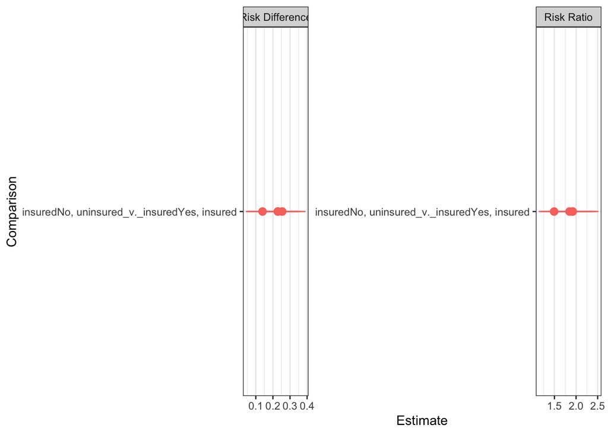

```r
#plotting! :)
library(ggplot2)
ggplot(colon.education.risk$results.df %>%
         filter(Parameter %in% c("Risk Difference", "Risk Ratio"))
) +
  geom_pointrange(aes(x = Comparison,
                      y = Estimate,
                      ymin = `2.5% CL`,
                      ymax = `97.5% CL`,
                      color = Comparison)
  ) +
  coord_flip() +
  facet_wrap(~Parameter, scale = "free") +
  theme_bw() +
  theme(legend.position = "none")
```

```r
colon.college.risk <- gComp(data = mydata, Y= "colonoscopy10yr19", X= "insured",
                           subgroup="college",
                           outcome.type = "binary", R = 200)
summary(colon.college.risk)
```

```
## Formula:
## colonoscopy10yr19 ~ insured + +insured:college
##
## Family: binomial
## Link function: logit
##
## Contrast: insuredNo, uninsured v. insuredYes, insured
##
## Parameter estimates:
##                             insuredNo, uninsured_v._insuredYes, insured_college0 Estimate (95% CI)
## Risk Difference                                                               0.201 (0.128, 0.275)
## Risk Ratio                                                                    1.726 (1.456, 2.018)
## Odds Ratio                                                                    2.387 (1.772, 3.257)
## Number needed to treat/harm                                                                  4.987
##                             insuredNo, uninsured_v._insuredYes, insured_college1 Estimate (95% CI)
## Risk Difference                                                               0.229 (0.097, 0.339)
## Risk Ratio                                                                    1.918 (1.371, 2.453)
## Odds Ratio                                                                    2.758 (1.578, 4.398)
## Number needed to treat/harm                                                                  4.374
##
## Underlying glm:
## Call:  stats::glm(formula = formula, family = family, data = working.df,
##     na.action = stats::na.omit)
##
## Coefficients:
##                   (Intercept)           insuredNo, uninsured
##                     -0.963188                       0.870097
##  insuredYes, insured:college1  insuredNo, uninsured:college1
##                     -0.140900                       0.003478
##
## Degrees of Freedom: 4041 Total (i.e. Null);  4038 Residual
##   (4735 observations deleted due to missingness)
## Null Deviance:       4767
## Residual Deviance: 4717  AIC: 4725
```

```r
library(interactionR)
#interaction
#with interactionR you may run into a problem of "At least one of the exposure names you have identified cannot be found in your model - You have to change the variables to straight 0/1 instead of the 1/2 found in CHS data
fit.interaction <- glm(recentcolonoscopy~hasinsurance*college,
                   data=mydata,
                   family = binomial(link = "logit"))

interactionR(fit.interaction,
exposure_names = c("college", "hasinsurance"),
ci.type = "delta", ci.level = 0.95,
em = F,  #T for EMM, F for interaction
recode = T
) %>%
interactionR_table(p.value=TRUE) %>%
             knit_print()
```

[output not shown]

Interaction of college and hasinsurance

|  | hasinsurance absent | hasinsurance present | Effect of hasinsurance within the strata of college |
| --- | --- | --- | --- |
|  | OR [95% CI] | OR [95% CI] | OR [95% CI] |
| college absent | 1 [Reference] | 2.76 [1.69, 4.51] p=5.27198473118074e-05 | 2.76 [1.69, 4.51] p=5.27198473118074e-05 |
| college present | 1 [0.57, 1.77] p=0.990374587865108 | 2.4 [1.47, 3.91] p=0.00049320986179968 | 2.39 [1.74, 3.27] p=9.68451305523203e-08 |
| Effect of college within the strata of hasinsurance | 1 [0.57, 1.77] p=0.990374587865108 | 0.87 [0.75, 1] p=0.0574871724461189 |  |
| Multiplicative scale | 0.87 [0.48, 1.55] p=0.627733289460515 |  |  |
| RERI | -0.37 [-1.18, 0.45] p=0.810789492466884 |  |  |
| AP | -0.15 [-0.44, 0.14] p=0.150631785097557 |  |  |
| SI | 0.79 [0.56, 1.13] p=0.39117749786784 |  |  |

```r
#RERI<0 implies negative additive interaction
#Multiplicative<1 implies negative multiplicative interaction
interactionR(fit.interaction,
exposure_names = c("college", "hasinsurance"),
ci.type = "delta", ci.level = 0.95,
em = T,
recode = T
) %>%
interactionR_table(p.value=TRUE) %>%
             knit_print()
```

[output not shown]

Modification of the effect of college and hasinsurance

|  | hasinsurance absent | hasinsurance present | Effect of hasinsurance within the strata of college |
| --- | --- | --- | --- |
|  | OR [95% CI] | OR [95% CI] | OR [95% CI] |
| college absent | 1 [Reference] | 2.76 [1.69, 4.51] p=5.27198473118074e-05 | 2.76 [1.69, 4.51] p=5.27198473118074e-05 |
| college present | 1 [0.57, 1.77] p=0.990374587865108 | 2.4 [1.47, 3.91] p=0.00049320986179968 | 2.39 [1.74, 3.27] p=9.68451305523203e-08 |
| Multiplicative scale | 0.87 [0.48, 1.55] p=0.627733289460515 |  |  |
| RERI | -0.37 [-1.18, 0.45] p=0.810789492466884 |  |  |

## Lab 5 - Mediation

Exposure: Insurance Outcome: Recent Colonoscopy Confounder: Age Mediator: PCP

```r
library(mediation)
library(table1)
mydata <- mydata %>%
           filter(!is.na(colonoscopy10yr19),
                  !is.na(pcp19),
                  !is.na(hasinsurance))
mydata <- mydata %>%
  mutate(haspcp=case_when(
    mydata$pcp19=="Yes PCP" ~ 1,
    mydata$pcp19=="No PCP" ~0
  ))

table1(~insured + age50up + pcp19 | colonoscopy10yr19, data=mydata, overall="Total", extra.col=list(`P-value`=pvalue))
```

|  | Less than 10 yrs ago (N=2922) | Never or >=10yr (N=1121) | Total (N=4043) | P-value |
| --- | --- | --- | --- | --- |
| Insured? |  |  |  |  |
| Yes, insured | 2795 (95.7%) | 1006 (89.7%) | 3801 (94.0%) | <0.001 |
| No, uninsured | 127 (4.3%) | 115 (10.3%) | 242 (6.0%) |  |
| age50up |  |  |  |  |
| 50-64 Yrs | 1409 (48.2%) | 624 (55.7%) | 2033 (50.3%) | <0.001 |
| 65+ | 1513 (51.8%) | 497 (44.3%) | 2010 (49.7%) |  |
| pcp19 |  |  |  |  |
| Yes PCP | 2762 (94.5%) | 982 (87.6%) | 3744 (92.6%) | <0.001 |
| No PCP | 160 (5.5%) | 139 (12.4%) | 299 (7.4%) |  |

```r
#What is the relationship between Insurance (exposure) and Recent colonoscopy (outcome)?
gComp(data=mydata, Y="colonoscopy10yr19", X="insured", outcome.type="binary")%>%
summary()
```

```
## Formula:
## colonoscopy10yr19 ~ insured
##
## Family: binomial
## Link function: logit
##
## Contrast: insuredNo, uninsured v. insuredYes, insured
##
## Parameter estimates:
##                             insuredNo, uninsured_v._insuredYes, insured Estimate (95% CI)
## Risk Difference                                                      0.210 (0.135, 0.268)
## Risk Ratio                                                           1.796 (1.493, 2.033)
## Odds Ratio                                                           2.516 (1.833, 3.225)
## Number needed to treat/harm                                                         4.750
##
## Underlying glm:
## Call:  stats::glm(formula = formula, family = family, data = working.df,
##     na.action = stats::na.omit)
##
## Coefficients:
##          (Intercept)  insuredNo, uninsured
##              -1.0219                0.9226
##
## Degrees of Freedom: 4042 Total (i.e. Null);  4041 Residual
## Null Deviance:       4774
## Residual Deviance: 4728  AIC: 4732
```

```r
#What is the relationship between Insurance(exposure)and having PCP (mediator)?
gComp(data=mydata, Y="pcp19", X="insured", outcome.type="binary") %>%
summary()
```

```
## Formula:
## pcp19 ~ insured
##
## Family: binomial
## Link function: logit
##
## Contrast: insuredNo, uninsured v. insuredYes, insured
##
## Parameter estimates:
##                             insuredNo, uninsured_v._insuredYes, insured Estimate (95% CI)
## Risk Difference                                                      0.339 (0.276, 0.389)
## Risk Ratio                                                           7.314 (5.905, 8.636)
## Odds Ratio                                                         11.395 (8.654, 14.351)
## Number needed to treat/harm                                                         2.951
##
## Underlying glm:
## Call:  stats::glm(formula = formula, family = family, data = working.df,
##     na.action = stats::na.omit)
##
## Coefficients:
##          (Intercept)  insuredNo, uninsured
##               -2.870                 2.433
##
## Degrees of Freedom: 4042 Total (i.e. Null);  4041 Residual
## Null Deviance:       2133
## Residual Deviance: 1914  AIC: 1918
```

```r
#What is the relation between PCP (mediator) and Colonoscopy (outcome)?
gComp(data=mydata, Y="colonoscopy10yr19", X="pcp19", outcome.type="binary") %>%
summary()
```

```
## Formula:
## colonoscopy10yr19 ~ pcp19
##
## Family: binomial
## Link function: logit
##
## Contrast: pcp19No PCP v. pcp19Yes PCP
##
## Parameter estimates:
##                             pcp19No PCP_v._pcp19Yes PCP Estimate (95% CI)
## Risk Difference                                      0.203 (0.144, 0.261)
## Risk Ratio                                           1.772 (1.536, 2.032)
## Odds Ratio                                           2.443 (1.913, 3.135)
## Number needed to treat/harm                                         4.936
##
## Underlying glm:
## Call:  stats::glm(formula = formula, family = family, data = working.df,
##     na.action = stats::na.omit)
##
## Coefficients:
## (Intercept)  pcp19No PCP
##     -1.0341       0.8934
##
## Degrees of Freedom: 4042 Total (i.e. Null);  4041 Residual
## Null Deviance:       4774
## Residual Deviance: 4722  AIC: 4726
```

```r
#define control condition value
X_control <- mean(mydata$haspcp)-sd(mydata$haspcp)
#define treatment condition value
X_treatment <-mean(mydata$haspcp)+sd(mydata$haspcp)
# (M on X)
a1<-glm(data=mydata, haspcp~hasinsurance+age50up, family=binomial(link="logit"))
a1.0 <-a1$coefficients[1]
a1.1 <- a1$coefficients[2]
#Y~X+M
b1<-glm(data=mydata, recentcolonoscopy~hasinsurance+haspcp+age50up, family=binomial(link="logit"))
b1.0 <- b1$coefficients[1]
c1 <-b1$coefficients[2]
b1.1 <- b1$coefficients[3]


#calculate estimated mediator for control/treatment conditions
M_est_control <- (a1.0+a1.1*X_control)
M_est_treatment <- (a1.0+a1.1*X_treatment)

#indirect effect - control
IE_control <- (1/(1+exp(-(b1.0+b1.1*M_est_treatment+c1*X_control)))-1/(1+exp(-(b1.0+b1.1*M_est_control+c1*X_control))))
print(IE_control)
```

```
## (Intercept)
##   0.1024422
```

```r
#indirect effect - treatment
IE_treatment <- (1/(1+exp(-(b1.0+b1.1*M_est_treatment+c1*X_treatment)))-1/(1+exp(-(b1.0+b1.1*M_est_control+c1*X_treatment))))
print(IE_treatment)
```

```
## (Intercept)
##   0.0800002
```

```r
m1<-mediate(a1, b1, outcome="recentcolonoscopy", treat="hasinsurance", mediator="haspcp")
  summary(m1)
```

```
##
## Causal Mediation Analysis
##
## Quasi-Bayesian Confidence Intervals
##
##                          Estimate 95% CI Lower 95% CI Upper p-value
## ACME (control)             0.0570       0.0353         0.08  <2e-16 ***
## ACME (treated)             0.0511       0.0308         0.08  <2e-16 ***
## ADE (control)              0.1433       0.0695         0.21  <2e-16 ***
## ADE (treated)              0.1374       0.0656         0.21  <2e-16 ***
## Total Effect               0.1944       0.1221         0.26  <2e-16 ***
## Prop. Mediated (control)   0.2915       0.1630         0.49  <2e-16 ***
## Prop. Mediated (treated)   0.2598       0.1397         0.46  <2e-16 ***
## ACME (average)             0.0541       0.0332         0.08  <2e-16 ***
## ADE (average)              0.1404       0.0675         0.21  <2e-16 ***
## Prop. Mediated (average)   0.2757       0.1519         0.47  <2e-16 ***
## ---
## Signif. codes:  0 '***' 0.001 '**' 0.01 '*' 0.05 '.' 0.1 ' ' 1
##
## Sample Size Used: 4043
##
##
## Simulations: 1000
```

```r
  #ACME = average causal mediation effect (indirect effect)
  #ADE = average direct effect
```

TE - change in Y from exposure 0->1 while mediator is allowed to trak the change in T

CDE- change in Y comparing exposed and unexposed with pre-set Mediator level (M=0)

NDE - change in Y from exposued to unexposed with mediator set at whatever value it would have attained for each individual at E=0

NIE - change in Y when E=0 and M = value at E=1

CDE = NDE if there is no interaction.

TE=NDE+NIE

## Lab 6 - Selection Bias & Models

## Lab 7 - Cohort Studies